# 第12回 課題の答え合わせ

基本TODO①〜④と応用①②③

# 基本TODO

## TODO①：コードのセルの1行目

```python
for i, cell in enumerate(nb['cells']):
    if cell['cell_type'] == 'code':
        print(i, cell['source'][0].strip())
```

```
1 import re,os                      3 SHP=(30,30,3)
5 def rescale(a):                   7 import matplotlib.image as mpi
9 raw_data,indexes=get_data()       11 pca=PCA(.96).fit(norm_data)
12 examples=[0,6,10,11,24,33,43,4   14 k=12
16 lik_idx=indexes[np.argsort(lik   18 L=[]
20 pca_all=PCA().fit(norm_data)     22 recon_data=np.dot(scores,pca.c
24 L=[]                             26 from pyppca import ppca
27 Example generation               28 norm_samp=norm_data[inc_idx]
31 np.random.seed(1)                33 from sklearn.cluster import Af
34 import os
```

## 1行目は、リストの0番目

- `cell['source']`は、中身を行ごとに分けたリスト
- `[0]`で1行目。`.strip()`で末尾の改行を消す

## TODO②：外す条件

```python
print([x[:, :, i].max() == 0 for i in range(3)])
print(x.std() != 0)
```

```
[np.False_, np.False_, np.False_]
True
```

- `get_data`の中の条件を、1つの銀河で取り出して試す

## TODO③：90%は3個

```python
cum = np.cumsum(PCA().fit(norm_data).explained_variance_ratio_)
print(np.argmax(cum >= 0.9) + 1)
```

```
3
```

- 第9回の顔と、同じ書き方

## TODO④：2番目のグループ

```python
second = indexes[clust.labels_ == sizes.index[1]]
make_image(second[:30], (5, 6))
plt.show()
```

[output not shown]

- `sizes.index[1]`：数の多い順で2番目のグループの番号

# 課題

## 応用①：回転をそろえない

```python
L, U = np.quantile(raw_data, [0, .99])
clip_only = np.clip(raw_data, L, U)        # 回転をそろえない
pca_r = PCA(.96).fit(clip_only)
print(pca_r.n_components_, pca_r.explained_variance_ratio_[:3].round(3))
pca_keep = pca                             # 4節の PCA を取っておく
pca = pca_r
exec(author(24))                           # 回転なしの固有銀河
pca = pca_keep
```

## 名前を差し替えて、セルを使い回す

- 24番のセルは、`pca`という名前のPCAを描く
- `pca`を差し替えてから実行し、終わったら元に戻す

## 応用②：主成分の数

```
答え: 14
```

- 正答は14
- 回転をそろえたときは、10

## 回転をそろえたとき

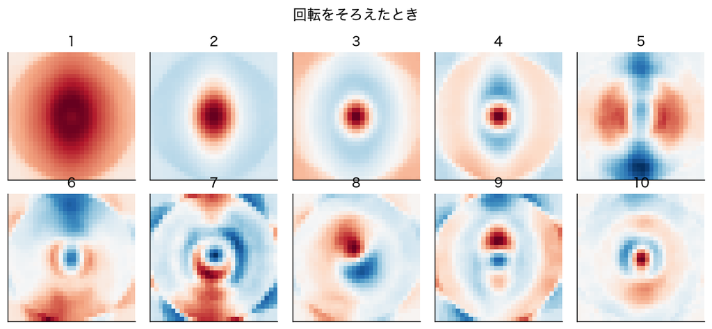

- 2番目に、縦に伸びた中心

## そろえないとき

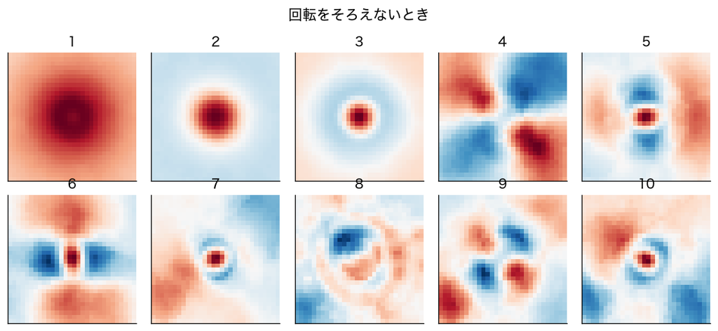

- 斜めや横など、いろいろな向きの成分が混ざる

## 向きの違いに、成分を使ってしまう

- 向きが違うだけの同じ形を、別々の成分で表すことになる
- そのぶん、固有銀河の数が増える

## 応用③：模範例

回転をそろえたときは10個の固有銀河で96%を表せましたが、そろえないと14個が要りました。そろえないときの固有銀河には、同じ伸びた形を、いろいろな向きで表すための成分が混ざります。

向きが違うだけの同じ形を、別々の成分で表すことになるので、そのぶん固有銀河の数が増えます。回転をそろえると、同じ96%に要る数が14個から10個に減ります。

論文の「約12個」という少なさは、向きをそろえる段を含めた数です。論文の数と比べるときは、この1段を省かずに再現する必要があります。

## 書き方の型

- 1段落目：数で比べる（10個と14個）。固有銀河の形の違い
- 2段落目：なぜ数が増えるか
- 3段落目：論文の数にとっての意味

# まとめ

## まとめと、発展動画へ

- 他人のコードは、条件を取り出して試すと読める
- パイプラインの1段は、外して比べると意味が分かる

発展動画：脳のfMRIを、似た動きの区画に分ける。